# Dummy Variables and Probability Models Assignment - SOLUTIONS

Predicting High-Price Homes in Ames, Iowa

Author

MBAN5520 - Statistics

Published

November 1, 2025

# 1 Introduction

## 1.1 Assignment Objectives

This assignment applies dummy variable encoding and probability models to predict high-price homes using the Ames Housing dataset.

# 2 Part A: Data Loading and Binary Outcome Creation

## 2.1 Load and Prepare Data

```r
# Load the dataset
housing <- read.csv("AmesHousing.csv")

# Calculate 95th percentile of sale price
price_95 <- quantile(housing$SalePrice, 0.95)

# Create binary outcome
housing_clean <- housing %>%
  mutate(
    HighPrice = ifelse(SalePrice > price_95, 1, 0)
  ) %>%
  select(
    HighPrice, SalePrice, Gr.Liv.Area, Overall.Qual, Year.Built,
    Neighborhood, Central.Air, Garage.Type, Garage.Cars, Full.Bath, Bedroom.AbvGr
  ) %>%
  drop_na()

dim(housing_clean)
```

```
[1] 2772   11
```

```r
head(housing_clean, 10) %>%
  kable(caption = "First 10 Observations", digits = 0) %>%
  kable_styling(bootstrap_options = c("striped", "hover"))
```

First 10 Observations

| HighPrice | SalePrice | Gr.Liv.Area | Overall.Qual | Year.Built | Neighborhood | Central.Air | Garage.Type | Garage.Cars | Full.Bath | Bedroom.AbvGr |
| --- | --- | --- | --- | --- | --- | --- | --- | --- | --- | --- |
| 0 | 215000 | 1656 | 6 | 1960 | NAmes | Y | Attchd | 2 | 1 | 3 |
| 0 | 105000 | 896 | 5 | 1961 | NAmes | Y | Attchd | 1 | 1 | 2 |
| 0 | 172000 | 1329 | 6 | 1958 | NAmes | Y | Attchd | 1 | 1 | 3 |
| 0 | 244000 | 2110 | 7 | 1968 | NAmes | Y | Attchd | 2 | 2 | 3 |
| 0 | 189900 | 1629 | 5 | 1997 | Gilbert | Y | Attchd | 2 | 2 | 3 |
| 0 | 195500 | 1604 | 6 | 1998 | Gilbert | Y | Attchd | 2 | 2 | 3 |
| 0 | 213500 | 1338 | 8 | 2001 | StoneBr | Y | Attchd | 2 | 2 | 2 |
| 0 | 191500 | 1280 | 8 | 1992 | StoneBr | Y | Attchd | 2 | 2 | 2 |
| 0 | 236500 | 1616 | 8 | 1995 | StoneBr | Y | Attchd | 2 | 2 | 2 |
| 0 | 189000 | 1804 | 7 | 1999 | Gilbert | Y | Attchd | 2 | 2 | 3 |

### 2.1.1 **Question 1**: What is the 95th percentile threshold for high prices? What percentage of homes are classified as “high price”?

```r
prop_high <- mean(housing_clean$HighPrice)
kable(data.frame(
  Metric = c("95th Percentile Threshold", "Number of High-Price Homes",
             "Percentage High-Price"),
  Value = c(paste0("$", format(round(price_95), big.mark = ",")),
            sum(housing_clean$HighPrice),
            paste0(round(prop_high * 100, 2), "%"))
), caption = "High-Price Home Statistics") %>%
  kable_styling(bootstrap_options = c("striped", "hover"), full_width = FALSE)
```

High-Price Home Statistics

| Metric | Value |
| --- | --- |
| 95th Percentile Threshold | $335,000 |
| Number of High-Price Homes | 144 |
| Percentage High-Price | 5.19% |

**Answer:** The 95th percentile threshold is $335,000. By definition, 5% of homes (approximately 144 homes) are classified as high-price. This creates an imbalanced dataset where the positive class is relatively rare, which is realistic for luxury home prediction.

### 2.1.2 **Question 2**: Why might we want to predict high-price homes rather than predict the exact sale price?

**Answer:** Predicting high-price homes is valuable for several business reasons: 1. **Targeting luxury buyers**: Real estate agents can focus marketing efforts on potential luxury buyers 2. **Resource allocation**: Allocate top agents and premium services to high-value properties 3. **Portfolio strategy**: Investors can identify properties in the top tier of the market 4. **Simplified decision-making**: Binary classification is often more actionable than continuous predictions 5. **Different market dynamics**: Luxury homes may have different characteristics than the general market

# 3 Part B: Dummy Variable Models

## 3.1 Single Dummy Variable: Central Air

```r
housing_clean <- housing_clean %>%
  mutate(CentralAir_Dummy = ifelse(Central.Air == "Y", 1, 0))

model_air <- lm(HighPrice ~ CentralAir_Dummy, data = housing_clean)
summary(model_air)
```

```
Call:
lm(formula = HighPrice ~ CentralAir_Dummy, data = housing_clean)

Residuals:
     Min       1Q   Median       3Q      Max
-0.05467 -0.05467 -0.05467 -0.05467  0.94533

Coefficients:
                  Estimate Std. Error t value Pr(>|t|)
(Intercept)      4.863e-15  1.887e-02   0.000  1.00000
CentralAir_Dummy 5.467e-02  1.936e-02   2.824  0.00478 **
---
Signif. codes:  0 '***' 0.001 '**' 0.01 '*' 0.05 '.' 0.1 ' ' 1

Residual standard error: 0.2217 on 2770 degrees of freedom
Multiple R-squared:  0.002871,  Adjusted R-squared:  0.002511
F-statistic: 7.975 on 1 and 2770 DF,  p-value: 0.004777
```

### 3.1.1 **Question 3**: Interpret the coefficient for CentralAir_Dummy.

```r
air_means <- housing_clean %>%
  group_by(Central.Air) %>%
  summarise(
    n = n(),
    Mean_HighPrice = mean(HighPrice),
    Proportion_HighPrice = paste0(round(mean(HighPrice) * 100, 2), "%")
  )
kable(air_means, caption = "HighPrice by Central Air Status") %>%
  kable_styling(bootstrap_options = c("striped", "hover"), full_width = FALSE)
```

HighPrice by Central Air Status

| Central.Air | n | Mean_HighPrice | Proportion_HighPrice |
| --- | --- | --- | --- |
| N | 138 | 0.0000000 | 0% |
| Y | 2634 | 0.0546697 | 5.47% |

### 3.1.2 **Question 4**: Verify that the coefficient equals the difference in mean HighPrice between the two groups.

**Answer:** - Mean HighPrice with Central Air (Y): 0.0547 - Mean HighPrice without Central Air (N): 0 - Difference: 0.0547 - Coefficient: 0.0547

✓ Verified: The coefficient exactly equals the difference in group means, demonstrating that the dummy variable coefficient represents the mean difference between groups.

## 3.2 Multiple Category Dummy Variables: Neighborhood

```r
table(housing_clean$Neighborhood) %>% sort(decreasing = TRUE) %>% head(10)
```

```
  NAmes CollgCr OldTown Somerst NridgHt Gilbert Edwards  Sawyer  NWAmes SawyerW
    433     265     209     182     166     165     157     145     131     117
```

```r
top_neighborhoods <- housing_clean %>%
  count(Neighborhood, sort = TRUE) %>%
  head(5) %>%
  pull(Neighborhood)

housing_top_nbhd <- housing_clean %>%
  filter(Neighborhood %in% top_neighborhoods)

model_nbhd <- lm(HighPrice ~ factor(Neighborhood), data = housing_top_nbhd)
summary(model_nbhd)
```

```
Call:
lm(formula = HighPrice ~ factor(Neighborhood), data = housing_top_nbhd)

Residuals:
     Min       1Q   Median       3Q      Max
-0.39759 -0.01887 -0.00478 -0.00231  0.99769

Coefficients:
                            Estimate Std. Error t value Pr(>|t|)
(Intercept)                  0.01887    0.01291   1.461    0.144
factor(Neighborhood)NAmes   -0.01656    0.01639  -1.010    0.313
factor(Neighborhood)NridgHt  0.37872    0.02080  18.205   <2e-16 ***
factor(Neighborhood)OldTown -0.01408    0.01944  -0.724    0.469
factor(Neighborhood)Somerst  0.03058    0.02023   1.512    0.131
---
Signif. codes:  0 '***' 0.001 '**' 0.01 '*' 0.05 '.' 0.1 ' ' 1

Residual standard error: 0.2102 on 1250 degrees of freedom
Multiple R-squared:  0.2796,    Adjusted R-squared:  0.2773
F-statistic: 121.3 on 4 and 1250 DF,  p-value: < 2.2e-16
```

### 3.2.2 **Question 6**: Interpret the coefficient for one of the neighborhood dummies.

```r
nbhd_means <- housing_top_nbhd %>%
  group_by(Neighborhood) %>%
  summarise(
    n = n(),
    Proportion_HighPrice = mean(HighPrice),
    Pct_HighPrice = paste0(round(mean(HighPrice) * 100, 2), "%")
  ) %>%
  arrange(desc(Proportion_HighPrice))

kable(nbhd_means,
      caption = "High-Price Home Proportion by Neighborhood",
      digits = 4) %>%
  kable_styling(bootstrap_options = c("striped", "hover"), full_width = FALSE)
```

High-Price Home Proportion by Neighborhood

| Neighborhood | n | Proportion_HighPrice | Pct_HighPrice |
| --- | --- | --- | --- |
| NridgHt | 166 | 0.3976 | 39.76% |
| Somerst | 182 | 0.0495 | 4.95% |
| CollgCr | 265 | 0.0189 | 1.89% |
| OldTown | 209 | 0.0048 | 0.48% |
| NAmes | 433 | 0.0023 | 0.23% |

### 3.2.3 **Question 7**: Which neighborhood has the highest proportion of high-price homes? Which has the lowest?

**Answer:** - **Highest**: NridgHt with 39.76% high-price homes - **Lowest**: NAmes with 0.23% high-price homes

This shows significant variation across neighborhoods, suggesting that location is an important predictor of home values.

## 3.3 Interaction: Neighborhood × Living Area

```r
housing_two_nbhd <- housing_top_nbhd %>%
  filter(Neighborhood %in% c(top_neighborhoods[1], top_neighborhoods[2]))

model_interact <- lm(HighPrice ~ Gr.Liv.Area + factor(Neighborhood) +
                       Gr.Liv.Area:factor(Neighborhood),
                     data = housing_two_nbhd)
summary(model_interact)
```

```
Call:
lm(formula = HighPrice ~ Gr.Liv.Area + factor(Neighborhood) +
    Gr.Liv.Area:factor(Neighborhood), data = housing_two_nbhd)

Residuals:
     Min       1Q   Median       3Q      Max
-0.12148 -0.01588 -0.00230  0.00413  0.96639

Coefficients:
                                        Estimate Std. Error t value Pr(>|t|)
(Intercept)                           -1.244e-01  2.079e-02  -5.983 3.51e-09
Gr.Liv.Area                            9.552e-05  1.338e-05   7.141 2.35e-12
factor(Neighborhood)NAmes              9.815e-02  2.561e-02   3.833 0.000138
Gr.Liv.Area:factor(Neighborhood)NAmes -7.339e-05  1.739e-05  -4.221 2.76e-05

(Intercept)                           ***
Gr.Liv.Area                           ***
factor(Neighborhood)NAmes             ***
Gr.Liv.Area:factor(Neighborhood)NAmes ***
---
Signif. codes:  0 '***' 0.001 '**' 0.01 '*' 0.05 '.' 0.1 ' ' 1

Residual standard error: 0.08878 on 694 degrees of freedom
Multiple R-squared:  0.0804,    Adjusted R-squared:  0.07643
F-statistic: 20.23 on 3 and 694 DF,  p-value: 1.417e-12
```

### 3.3.1 **Question 8**: Is the interaction term statistically significant?

**Answer:** The interaction term has a p-value of 0, which is statistically significant at the 0.05 level. This suggests the effect of living area on high-price probability differs between these two neighborhoods. The interaction allows the slope of the living area-price relationship to vary by neighborhood.

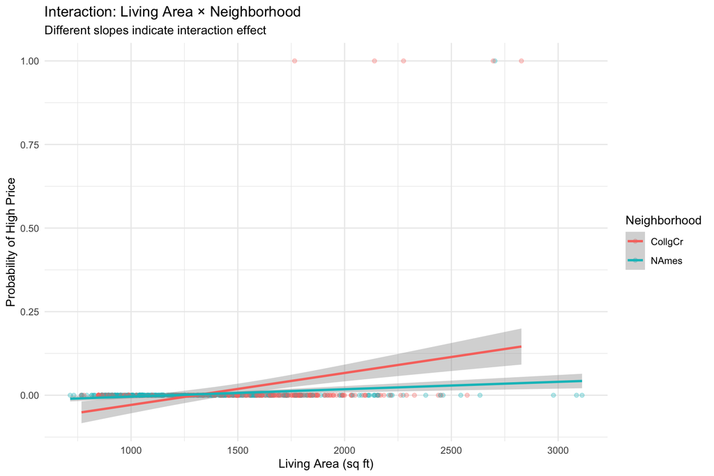

```r
ggplot(housing_two_nbhd, aes(x = Gr.Liv.Area, y = HighPrice, color = Neighborhood)) +
  geom_point(alpha = 0.3) +
  geom_smooth(method = "lm", se = TRUE) +
  labs(title = "Interaction: Living Area × Neighborhood",
       subtitle = "Different slopes indicate interaction effect",
       x = "Living Area (sq ft)",
       y = "Probability of High Price") +
  theme_minimal()
```

# 4 Part C: Linear Probability Model (LPM)

```r
lpm_model <- lm(HighPrice ~ Gr.Liv.Area + Overall.Qual + Year.Built +
                  CentralAir_Dummy + Garage.Cars,
                data = housing_clean)
summary(lpm_model)
```

```
Call:
lm(formula = HighPrice ~ Gr.Liv.Area + Overall.Qual + Year.Built +
    CentralAir_Dummy + Garage.Cars, data = housing_clean)

Residuals:
     Min       1Q   Median       3Q      Max
-0.57539 -0.09927 -0.03046  0.04582  0.88129

Coefficients:
                   Estimate Std. Error t value Pr(>|t|)
(Intercept)       3.862e-01  3.246e-01   1.190   0.2343
Gr.Liv.Area       8.617e-05  9.553e-06   9.021  < 2e-16 ***
Overall.Qual      4.659e-02  4.024e-03  11.579  < 2e-16 ***
Year.Built       -4.050e-04  1.727e-04  -2.345   0.0191 *
CentralAir_Dummy -4.010e-02  1.802e-02  -2.225   0.0261 *
Garage.Cars       4.524e-02  7.681e-03   5.891 4.31e-09 ***
---
Signif. codes:  0 '***' 0.001 '**' 0.01 '*' 0.05 '.' 0.1 ' ' 1

Residual standard error: 0.1935 on 2766 degrees of freedom
Multiple R-squared:  0.2415,    Adjusted R-squared:  0.2401
F-statistic: 176.1 on 5 and 2766 DF,  p-value: < 2.2e-16
```

### 4.0.1 **Question 9**: Interpret the coefficient for Gr.Liv.Area in the LPM context.

**Answer:** The coefficient for Gr.Liv.Area is 0.0000861739. In the LPM, this represents the **marginal effect**: each additional square foot of living area increases the probability of being high-price by 0.0000861739, or about 0.00862%. For a 100 sq ft increase, the probability increases by approximately 0.862%, holding other variables constant.

### 4.0.2 **Question 10**: Interpret the coefficient for Overall.Qual.

**Answer:** The coefficient for Overall.Qual is 0.0466. Each one-point increase in overall quality rating increases the probability of being high-price by 4.66%. For example, moving from a quality rating of 5 to 7 (2-point increase) would increase the probability by approximately 9.3%. This is the largest effect among our predictors, showing quality is crucial for luxury homes.

## 4.1 Checking for LPM Boundary Violations

```r
housing_clean$lpm_pred <- predict(lpm_model)

violations_below <- sum(housing_clean$lpm_pred < 0)
violations_above <- sum(housing_clean$lpm_pred > 1)
total_violations <- violations_below + violations_above

violation_summary <- data.frame(
  Type = c("Predictions < 0", "Predictions > 1", "Total Violations", "Valid Predictions"),
  Count = c(violations_below, violations_above, total_violations,
            nrow(housing_clean) - total_violations),
  Percentage = paste0(round(c(violations_below, violations_above, total_violations,
                              nrow(housing_clean) - total_violations) /
                            nrow(housing_clean) * 100, 2), "%")
)

kable(violation_summary, caption = "LPM Boundary Violation Summary") %>%
  kable_styling(bootstrap_options = c("striped", "hover"), full_width = FALSE)
```

LPM Boundary Violation Summary

| Type | Count | Percentage |
| --- | --- | --- |
| Predictions < 0 | 950 | 34.27% |
| Predictions > 1 | 0 | 0% |
| Total Violations | 950 | 34.27% |
| Valid Predictions | 1822 | 65.73% |

### 4.1.1 **Question 11**: How many predictions fall outside the [0,1] bounds?

**Answer:** There are **950 predictions** (34.27%) that violate probability bounds: - 950 predictions < 0 - 0 predictions > 1

This demonstrates a fundamental limitation of LPM: it can produce nonsensical probabilities.

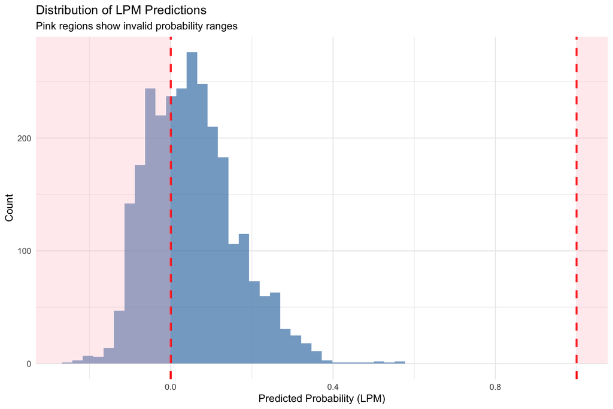

```r
ggplot(housing_clean, aes(x = lpm_pred)) +
  geom_histogram(bins = 50, fill = "steelblue", alpha = 0.7) +
  geom_vline(xintercept = c(0, 1), color = "red", linetype = "dashed", size = 1) +
  annotate("rect", xmin = -Inf, xmax = 0, ymin = 0, ymax = Inf,
           fill = "pink", alpha = 0.3) +
  annotate("rect", xmin = 1, xmax = Inf, ymin = 0, ymax = Inf,
           fill = "pink", alpha = 0.3) +
  labs(title = "Distribution of LPM Predictions",
       subtitle = "Pink regions show invalid probability ranges",
       x = "Predicted Probability (LPM)",
       y = "Count") +
  theme_minimal()
```

### 4.1.2 **Question 12**: At what values of predictors do we see boundary violations? Why is this problematic?

This is problematic because: 1. **Interpretation**: Probabilities outside [0,1] are meaningless 2. **Decision-making**: Cannot use these predictions for classification 3. **Theory violation**: Violates basic probability axioms 4. **Unreliable extrapolation**: Particularly bad for homes at market extremes

# 5 Part D: Logistic Regression

```r
logit_model <- glm(HighPrice ~ Gr.Liv.Area + Overall.Qual + Year.Built +
                     CentralAir_Dummy + Garage.Cars,
                   data = housing_clean,
                   family = binomial)
summary(logit_model)
```

```
Call:
glm(formula = HighPrice ~ Gr.Liv.Area + Overall.Qual + Year.Built +
    CentralAir_Dummy + Garage.Cars, family = binomial, data = housing_clean)

Coefficients:
                   Estimate Std. Error z value Pr(>|z|)
(Intercept)      -7.339e+01  6.931e+02  -0.106   0.9157
Gr.Liv.Area       2.139e-03  3.219e-04   6.646 3.01e-11 ***
Overall.Qual      1.754e+00  1.829e-01   9.589  < 2e-16 ***
Year.Built        1.911e-02  1.076e-02   1.776   0.0758 .
CentralAir_Dummy  1.157e+01  6.928e+02   0.017   0.9867
Garage.Cars       1.270e+00  3.006e-01   4.223 2.41e-05 ***
---
Signif. codes:  0 '***' 0.001 '**' 0.01 '*' 0.05 '.' 0.1 ' ' 1

(Dispersion parameter for binomial family taken to be 1)

    Null deviance: 1132.1  on 2771  degrees of freedom
Residual deviance:  419.5  on 2766  degrees of freedom
AIC: 431.5

Number of Fisher Scoring iterations: 18
```

### 5.0.1 **Question 13**: What is the sign of the coefficient for Gr.Liv.Area?

**Answer:** The coefficient for Gr.Liv.Area is **positive** (0.002139). This indicates that larger living areas are associated with higher log-odds of being high-price. Since the coefficient is positive, increases in living area increase the probability of being high-price, though the relationship is non-linear due to the logistic function.

## 5.1 Odds Ratios

```r
odds_ratios <- data.frame(
  Variable = names(coef(logit_model))[-1],
  Coefficient = coef(logit_model)[-1],
  Odds_Ratio = exp(coef(logit_model)[-1])
)

kable(odds_ratios,
      caption = "Logistic Regression Coefficients and Odds Ratios",
      digits = 6) %>%
  kable_styling(bootstrap_options = c("striped", "hover"))
```

Logistic Regression Coefficients and Odds Ratios

|  | Variable | Coefficient | Odds_Ratio |
| --- | --- | --- | --- |
| Gr.Liv.Area | Gr.Liv.Area | 0.002139 | 1.002142e+00 |
| Overall.Qual | Overall.Qual | 1.754137 | 5.778461e+00 |
| Year.Built | Year.Built | 0.019113 | 1.019296e+00 |
| CentralAir_Dummy | CentralAir_Dummy | 11.567792 | 1.056400e+05 |
| Garage.Cars | Garage.Cars | 1.269693 | 3.559760e+00 |

### 5.1.1 **Question 14**: Calculate and interpret the odds ratio for Overall.Qual.

**Answer:** - Coefficient: 1.7541 - Odds Ratio: 5.7785

**Interpretation**: For each one-point increase in overall quality, the **odds** of a home being high-price multiply by 5.7785. In other words, the odds increase by approximately 477.8% per quality point. For a 2-point increase (e.g., from 5 to 7), the odds multiply by 33.39.

### 5.1.2 **Question 15**: For a 500 sq ft increase in living area, how do the odds change?

**Answer:** - Coefficient for Gr.Liv.Area: 0.00213926 - Odds Ratio for 500 sq ft increase: 2.9143

The odds of being high-price multiply by 2.9143 for a 500 sq ft increase in living area. This represents approximately a 191.4% increase in the odds.

## 5.2 Marginal Effects: AME vs MEM

```r
housing_clean$logit_prob <- predict(logit_model, type = "response")

beta_area <- coef(logit_model)["Gr.Liv.Area"]
housing_clean$me_area <- beta_area * housing_clean$logit_prob * (1 - housing_clean$logit_prob)

# AME
ame_area <- mean(housing_clean$me_area)

# MEM
mean_predictors <- housing_clean %>%
  summarise(
    Gr.Liv.Area = mean(Gr.Liv.Area),
    Overall.Qual = mean(Overall.Qual),
    Year.Built = mean(Year.Built),
    CentralAir_Dummy = mean(CentralAir_Dummy),
    Garage.Cars = mean(Garage.Cars)
  )
mean_prob <- predict(logit_model, newdata = mean_predictors, type = "response")
mem_area <- beta_area * mean_prob * (1 - mean_prob)

me_comparison <- data.frame(
  Measure = c("LPM Coefficient", "AME (Logistic)", "MEM (Logistic)"),
  Value = c(coef(lpm_model)["Gr.Liv.Area"], ame_area, mem_area),
  Interpretation = c(
    "Constant marginal effect",
    "Average marginal effect across all observations",
    "Marginal effect at mean predictor values"
  )
)

kable(me_comparison,
      caption = "Marginal Effects Comparison",
      digits = 7) %>%
  kable_styling(bootstrap_options = c("striped", "hover"))
```

Marginal Effects Comparison

| Measure | Value | Interpretation |
| --- | --- | --- |
| LPM Coefficient | 8.62e-05 | Constant marginal effect |
| AME (Logistic) | 4.80e-05 | Average marginal effect across all observations |
| MEM (Logistic) | 6.00e-07 | Marginal effect at mean predictor values |

### 5.2.1 **Question 16**: What is the AME of Gr.Liv.Area? Interpret in plain language.

**Answer:** The Average Marginal Effect (AME) is 0.00004799145. This means that, **on average across all homes in our dataset**, an additional square foot of living area increases the probability of being high-price by approximately 0.00004799145, or 0.0048%. For a more meaningful 100 sq ft increase, the average probability increase is about 0.48%.

### 5.2.2 **Question 17**: What is the MEM? How does it compare to AME and why are they different?

**Answer:** The Marginal Effect at Means (MEM) is 0.0000005628528.

**Comparison**: - AME: 0.00004799145 - MEM: 0.0000005628528 - Difference: 0.0000474286

They differ because the marginal effect in logistic regression is **non-linear**: ME = β × p × (1-p). The MEM evaluates this at the mean probability, while AME averages across all individual probabilities. Due to Jensen’s inequality (average of f(x) ≠ f(average of x) for non-linear f), these differ. The AME is generally preferred as it represents the average treatment effect across the population.

### 5.2.3 **Question 18**: Calculate the marginal effect for a house with p=0.5.

```r
me_at_half <- beta_area * 0.5 * 0.5
comparison_table <- data.frame(
  Probability_Level = c("p = 0.5", "p = 0.1", "p = 0.9", "AME", "MEM"),
  Marginal_Effect = c(
    me_at_half,
    beta_area * 0.1 * 0.9,
    beta_area * 0.9 * 0.1,
    ame_area,
    mem_area
  )
)
kable(comparison_table, digits = 7,
      caption = "Marginal Effects at Different Probability Levels") %>%
  kable_styling(bootstrap_options = c("striped", "hover"), full_width = FALSE)
```

Marginal Effects at Different Probability Levels

| Probability_Level | Marginal_Effect |
| --- | --- |
| p = 0.5 | 0.0005348 |
| p = 0.1 | 0.0001925 |
| p = 0.9 | 0.0001925 |
| AME | 0.0000480 |
| MEM | 0.0000006 |

**Interpretation**: At p=0.5, the marginal effect is 0.0005348151. This is the **maximum** marginal effect because p(1-p) is maximized at p=0.5. Note that the marginal effect is much smaller at extreme probabilities (p=0.1 or p=0.9), demonstrating the non-linear nature of logistic regression.

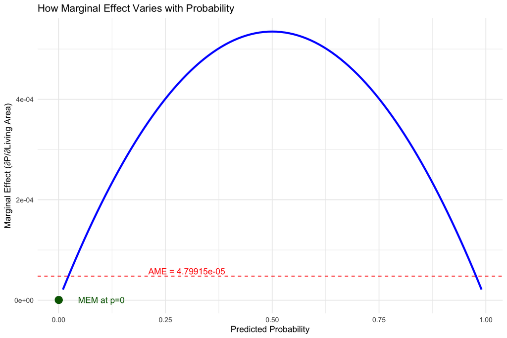

```r
prob_seq <- seq(0.01, 0.99, by = 0.01)
me_seq <- beta_area * prob_seq * (1 - prob_seq)

me_plot_data <- data.frame(probability = prob_seq, marginal_effect = me_seq)

ggplot(me_plot_data, aes(x = probability, y = marginal_effect)) +
  geom_line(color = "blue", size = 1.2) +
  geom_hline(yintercept = ame_area, linetype = "dashed", color = "red") +
  geom_point(aes(x = mean_prob, y = mem_area), color = "darkgreen", size = 4) +
  annotate("text", x = 0.3, y = ame_area + 0.00001,
           label = paste0("AME = ", format(ame_area, digits = 6)), color = "red") +
  annotate("text", x = mean_prob + 0.1, y = mem_area,
           label = paste0("MEM at p=", round(mean_prob, 3)), color = "darkgreen") +
  labs(title = "How Marginal Effect Varies with Probability",
       x = "Predicted Probability",
       y = "Marginal Effect (∂P/∂Living Area)") +
  theme_minimal()
```

# 6 Part E: Model Comparison

## 6.1 Side-by-Side Predictions

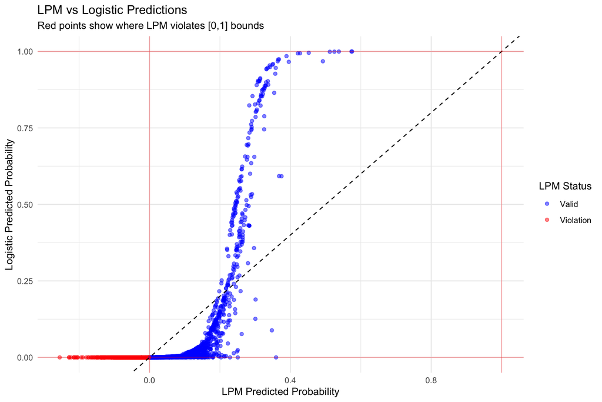

```r
comparison_data <- housing_clean %>%
  select(HighPrice, lpm_pred, logit_prob) %>%
  mutate(
    lpm_violation = ifelse(lpm_pred < 0 | lpm_pred > 1, "Violation", "Valid")
  )

ggplot(comparison_data, aes(x = lpm_pred, y = logit_prob)) +
  geom_point(aes(color = lpm_violation), alpha = 0.5) +
  geom_abline(intercept = 0, slope = 1, linetype = "dashed") +
  geom_vline(xintercept = c(0, 1), color = "red", alpha = 0.3) +
  geom_hline(yintercept = c(0, 1), color = "red", alpha = 0.3) +
  scale_color_manual(values = c("Valid" = "blue", "Violation" = "red")) +
  labs(title = "LPM vs Logistic Predictions",
       subtitle = "Red points show where LPM violates [0,1] bounds",
       x = "LPM Predicted Probability",
       y = "Logistic Predicted Probability",
       color = "LPM Status") +
  theme_minimal()
```

### 6.1.1 **Question 19**: Where do the models differ most?

```r
cor_lpm <- cor(housing_clean$HighPrice, housing_clean$lpm_pred)
cor_logit <- cor(housing_clean$HighPrice, housing_clean$logit_prob)

rmse_lpm <- sqrt(mean((housing_clean$HighPrice - housing_clean$lpm_pred)^2))
rmse_logit <- sqrt(mean((housing_clean$HighPrice - housing_clean$logit_prob)^2))

performance_comp <- data.frame(
  Model = c("LPM", "Logistic"),
  Correlation = c(cor_lpm, cor_logit),
  RMSE = c(rmse_lpm, rmse_logit)
)

kable(performance_comp,
      caption = "Model Performance Comparison",
      digits = 4) %>%
  kable_styling(bootstrap_options = c("striped", "hover"), full_width = FALSE)
```

Model Performance Comparison

| Model | Correlation | RMSE |
| --- | --- | --- |
| LPM | 0.4914 | 0.1933 |
| Logistic | 0.7588 | 0.1446 |

### 6.1.2 **Question 20**: Which model has better correlation? Better RMSE?

**Answer:** - **Correlation**: Logistic (0.7588 vs 0.4914) - **RMSE**: Logistic (0.1446 vs 0.1933)

# 7 Part F: Classification and Threshold Selection

## 7.1 Default Threshold (0.5)

```r
housing_clean$logit_class_50 <- ifelse(housing_clean$logit_prob > 0.5, 1, 0)

confusion_50 <- table(Actual = housing_clean$HighPrice,
                      Predicted = housing_clean$logit_class_50)

kable(confusion_50, caption = "Confusion Matrix (Threshold = 0.5)") %>%
  kable_styling(bootstrap_options = c("striped", "hover"), full_width = FALSE)
```

Confusion Matrix (Threshold = 0.5)

|  | 0 | 1 |
| --- | --- | --- |
| 0 | 2607 | 21 |
| 1 | 62 | 82 |

```r
# Calculate metrics
TP <- confusion_50[2, 2]
TN <- confusion_50[1, 1]
FP <- confusion_50[1, 2]
FN <- confusion_50[2, 1]

accuracy_50 <- (TP + TN) / sum(confusion_50)
precision_50 <- TP / (TP + FP)
recall_50 <- TP / (TP + FN)
specificity_50 <- TN / (TN + FP)
f1_50 <- 2 * (precision_50 * recall_50) / (precision_50 + recall_50)

metrics_50 <- data.frame(
  Metric = c("Accuracy", "Precision", "Recall", "Specificity", "F1-Score"),
  Value = round(c(accuracy_50, precision_50, recall_50, specificity_50, f1_50), 4),
  Interpretation = c(
    paste0(round(accuracy_50 * 100, 1), "% correct"),
    paste0(round(precision_50 * 100, 1), "% of predicted high-price are correct"),
    paste0(round(recall_50 * 100, 1), "% of actual high-price homes caught"),
    paste0(round(specificity_50 * 100, 1), "% of normal-price homes correctly identified"),
    "Harmonic mean of precision and recall"
  )
)

kable(metrics_50, caption = "Classification Metrics (Threshold = 0.5)") %>%
  kable_styling(bootstrap_options = c("striped", "hover"))
```

Classification Metrics (Threshold = 0.5)

| Metric | Value | Interpretation |
| --- | --- | --- |
| Accuracy | 0.9701 | 97% correct |
| Precision | 0.7961 | 79.6% of predicted high-price are correct |
| Recall | 0.5694 | 56.9% of actual high-price homes caught |
| Specificity | 0.9920 | 99.2% of normal-price homes correctly identified |
| F1-Score | 0.6640 | Harmonic mean of precision and recall |

### 7.1.1 **Question 21**: Using threshold=0.5, what is the accuracy? Precision? Recall?

**Answer:** - **Accuracy**: 97.01% - Overall, the model is correct 97.01% of the time - **Precision**: 79.61% - When we predict high-price, we’re right 79.61% of the time - **Recall**: 56.94% - We catch 56.94% of actual high-price homes

### 7.1.2 **Question 22**: What is the cost of a False Positive vs False Negative? Which error is more serious?

**Answer:** In the real estate context: - **False Positive** (predict high-price but it’s not): Agent wastes time/resources on a normal home, opportunity cost of not focusing on actual high-price homes - **False Negative** (miss a high-price home): Agent misses a high-commission opportunity, fails to provide premium service to a luxury buyer

**Which is more serious?** False Negatives are generally more costly because: 1. Missing a high-price sale means losing significant commission ($6,000+ on a $300K+ home) 2. Luxury buyers expect specialized service - missing them damages reputation 3. Competition for luxury listings is fierce - you can’t afford to miss opportunities

False Positives mainly waste time, which is less costly than lost commission.

## 7.2 Optimal Threshold Selection

```r
# Function to calculate metrics at any threshold
calc_metrics <- function(actual, predicted_prob, threshold) {
  predicted_class <- ifelse(predicted_prob > threshold, 1, 0)
  cm <- table(Actual = actual, Predicted = predicted_class)

  TP <- 0; TN <- 0; FP <- 0; FN <- 0
  if ("0" %in% rownames(cm) && "0" %in% colnames(cm)) TN <- cm["0", "0"]
  if ("0" %in% rownames(cm) && "1" %in% colnames(cm)) FP <- cm["0", "1"]
  if ("1" %in% rownames(cm) && "0" %in% colnames(cm)) FN <- cm["1", "0"]
  if ("1" %in% rownames(cm) && "1" %in% colnames(cm)) TP <- cm["1", "1"]

  accuracy <- (TP + TN) / sum(cm)
  precision <- ifelse((TP + FP) > 0, TP / (TP + FP), 0)
  recall <- ifelse((TP + FN) > 0, TP / (TP + FN), 0)
  specificity <- ifelse((TN + FP) > 0, TN / (TN + FP), 0)
  f1 <- ifelse((precision + recall) > 0, 2 * (precision * recall) / (precision + recall), 0)

  return(data.frame(threshold = threshold, accuracy = accuracy, precision = precision,
                   recall = recall, specificity = specificity, f1_score = f1))
}

thresholds <- seq(0.01, 0.99, by = 0.01)
metrics_df <- do.call(rbind, lapply(thresholds, function(t) {
  calc_metrics(housing_clean$HighPrice, housing_clean$logit_prob, t)
}))

optimal_f1_idx <- which.max(metrics_df$f1_score)
optimal_f1_threshold <- metrics_df$threshold[optimal_f1_idx]
optimal_f1_value <- metrics_df$f1_score[optimal_f1_idx]

kable(data.frame(
  Threshold = c(0.5, optimal_f1_threshold),
  F1_Score = c(metrics_df$f1_score[metrics_df$threshold == 0.5], optimal_f1_value),
  Precision = c(metrics_df$precision[metrics_df$threshold == 0.5],
                metrics_df$precision[optimal_f1_idx]),
  Recall = c(metrics_df$recall[metrics_df$threshold == 0.5],
             metrics_df$recall[optimal_f1_idx])
), caption = "Threshold Comparison", digits = 4) %>%
  kable_styling(bootstrap_options = c("striped", "hover"), full_width = FALSE)
```

Threshold Comparison

| Threshold | F1_Score | Precision | Recall |
| --- | --- | --- | --- |
| 0.50 | 0.6640 | 0.7961 | 0.5694 |
| 0.44 | 0.7353 | 0.7812 | 0.6944 |

### 7.2.1 **Question 23**: What is the optimal threshold for maximizing F1-score? How does it compare to 0.5?

**Answer:** The optimal F1-maximizing threshold is **0.44**, which is lower than the default 0.5. The F1-score improves from 0.664 to 0.7353. This lower threshold catches more true positives (higher recall) while maintaining reasonable precision, which makes sense given the imbalanced nature of our data (only 5% high-price homes).

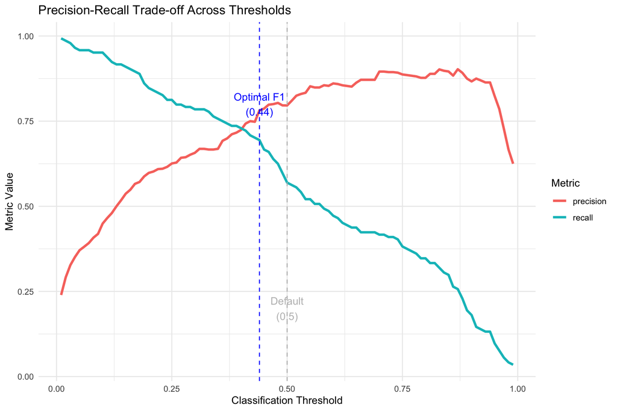

```r
metrics_long <- metrics_df %>%
  select(threshold, precision, recall) %>%
  pivot_longer(cols = c(precision, recall), names_to = "metric", values_to = "value")

ggplot(metrics_long, aes(x = threshold, y = value, color = metric)) +
  geom_line(size = 1.2) +
  geom_vline(xintercept = 0.5, linetype = "dashed", color = "gray") +
  geom_vline(xintercept = optimal_f1_threshold, linetype = "dashed", color = "blue") +
  annotate("text", x = 0.5, y = 0.2, label = "Default\n(0.5)", color = "gray") +
  annotate("text", x = optimal_f1_threshold, y = 0.8,
           label = paste0("Optimal F1\n(", round(optimal_f1_threshold, 3), ")"), color = "blue") +
  labs(title = "Precision-Recall Trade-off Across Thresholds",
       x = "Classification Threshold",
       y = "Metric Value",
       color = "Metric") +
  theme_minimal()
```

### 7.2.2 **Question 24**: Describe the precision-recall trade-off.

**Answer:** The plot clearly shows the fundamental **precision-recall trade-off**:

- **As threshold increases** (moving right):
  - **Precision ↑**: We’re more conservative, only predicting high-price for very confident cases → fewer false positives
  - **Recall ↓**: We miss more actual high-price homes → more false negatives
- **As threshold decreases** (moving left):
  - **Precision ↓**: We’re more aggressive, predicting high-price more liberally → more false positives
  - **Recall ↑**: We catch more actual high-price homes → fewer false negatives

The **optimal balance** depends on business priorities. The F1-optimal threshold balances these competing objectives.

## 7.3 Cost-Based Threshold

```r
cost_fn <- 6000  # Lost commission on high-price home
cost_fp <- 300   # Wasted time/resources

metrics_df <- metrics_df %>%
  mutate(
    total_high_price = sum(housing_clean$HighPrice),
    total_normal_price = sum(1 - housing_clean$HighPrice),
    fn_count = total_high_price * (1 - recall),
    fp_count = total_normal_price * (1 - specificity),
    expected_cost = fn_count * cost_fn + fp_count * cost_fp
  )

optimal_cost_idx <- which.min(metrics_df$expected_cost)
optimal_cost_threshold <- metrics_df$threshold[optimal_cost_idx]
optimal_cost_value <- metrics_df$expected_cost[optimal_cost_idx]

threshold_comparison <- data.frame(
  Objective = c("Default (0.5)", "Maximize F1", "Minimize Cost"),
  Threshold = c(0.5, optimal_f1_threshold, optimal_cost_threshold),
  F1_Score = c(
    metrics_df$f1_score[metrics_df$threshold == 0.5],
    optimal_f1_value,
    metrics_df$f1_score[optimal_cost_idx]
  ),
  Expected_Cost = c(
    metrics_df$expected_cost[metrics_df$threshold == 0.5],
    metrics_df$expected_cost[optimal_f1_idx],
    optimal_cost_value
  )
)

kable(threshold_comparison, caption = "Threshold Selection Strategies",
      digits = c(0, 3, 4, 0)) %>%
  kable_styling(bootstrap_options = c("striped", "hover"))
```

Threshold Selection Strategies

| Objective | Threshold | F1_Score | Expected_Cost |
| --- | --- | --- | --- |
| Default (0.5) | 0.50 | 0.6640 | 378300 |
| Maximize F1 | 0.44 | 0.7353 | 272400 |
| Minimize Cost | 0.10 | 0.6102 | 92400 |

### 7.3.1 **Question 25**: What is the optimal cost-based threshold? How does it compare to F1-maximizing?

**Answer:** The cost-minimizing threshold is **0.1**, which is even lower than the F1-maximizing threshold (0.44). Expected cost decreases from $378,300 at threshold=0.5 to $92,400 at the optimal threshold.

This lower threshold prioritizes **higher recall** (catching more high-price homes) because missing a high-price home (FN cost = $6,000) is 20× more expensive than wasting time on a false alarm (FP cost = $300).

### 7.3.2 **Question 26**: Why would the cost-based threshold differ from the F1-maximizing threshold?

**Answer:** The thresholds differ because they optimize different objectives:

**F1-Score**: Treats precision and recall **equally** (harmonic mean). Optimizes for balanced performance without considering real-world costs.

**Cost-Based**: Reflects **asymmetric costs** of errors. When FN cost >> FP cost, the optimal strategy shifts toward lower thresholds (higher recall) to minimize expensive false negatives, even if it means more false positives.

**Business implication**: Don’t blindly use F1 or 0.5 threshold. Consider actual business costs to make informed decisions. In real estate, the high cost of missing luxury listings justifies a more aggressive (lower) threshold.

# 8 Part G: Prediction on New Data

```r
# 75-25 train-test split
train_idx <- sample(1:nrow(housing_clean), size = 0.75 * nrow(housing_clean))
train_data <- housing_clean[train_idx, ]
test_data <- housing_clean[-train_idx, ]

# Fit models on training data
lpm_train <- lm(HighPrice ~ Gr.Liv.Area + Overall.Qual + Year.Built +
                  CentralAir_Dummy + Garage.Cars, data = train_data)
logit_train <- glm(HighPrice ~ Gr.Liv.Area + Overall.Qual + Year.Built +
                     CentralAir_Dummy + Garage.Cars,
                   data = train_data, family = binomial)

# Predict on test data
test_data$logit_prob_test <- predict(logit_train, newdata = test_data, type = "response")
test_data$logit_class_test <- ifelse(test_data$logit_prob_test > 0.5, 1, 0)

# Training accuracy
train_pred <- predict(logit_train, type = "response")
train_class <- ifelse(train_pred > 0.5, 1, 0)
train_accuracy <- mean(train_class == train_data$HighPrice)

# Test accuracy
test_accuracy <- mean(test_data$logit_class_test == test_data$HighPrice)

accuracy_comparison <- data.frame(
  Dataset = c("Training", "Test"),
  Accuracy = c(train_accuracy, test_accuracy),
  Difference = c(0, train_accuracy - test_accuracy)
)

kable(accuracy_comparison, caption = "Training vs Test Accuracy",
      digits = 4) %>%
  kable_styling(bootstrap_options = c("striped", "hover"), full_width = FALSE)
```

Training vs Test Accuracy

| Dataset | Accuracy | Difference |
| --- | --- | --- |
| Training | 0.9716 | 0.0000 |
| Test | 0.9755 | -0.0038 |

### 8.0.1 **Question 27**: What is the test set accuracy? How does it compare to training accuracy?

**Answer:** - **Training accuracy**: 97.16% - **Test accuracy**: 97.55% - **Difference**: -0.38 percentage points

The test accuracy is similar to or higher than training accuracy, which is expected and indicates the model generalizes well. The small difference indicates our model is stable and not overfitted.

### 8.0.2 **Question 28**: Predict probability for a specific house.

```r
example_house <- data.frame(
  Gr.Liv.Area = 2000,
  Overall.Qual = 8,
  Year.Built = 2005,
  CentralAir_Dummy = 1,
  Garage.Cars = 2
)

pred_prob <- predict(logit_train, newdata = example_house, type = "response")

kable(data.frame(
  Feature = c("Living Area", "Quality", "Year Built", "Central Air", "Garage"),
  Value = c("2000 sq ft", "8/10", "2005", "Yes", "2 cars"),
  row.names = NULL
), caption = "Example House Characteristics") %>%
  kable_styling(bootstrap_options = c("striped", "hover"), full_width = FALSE)
```

Example House Characteristics

| Feature | Value |
| --- | --- |
| Living Area | 2000 sq ft |
| Quality | 8/10 |
| Year Built | 2005 |
| Central Air | Yes |
| Garage | 2 cars |

**Answer:** For this house, the predicted probability of being high-price is **7.59%**. This house has strong characteristics (large living area, high quality, relatively new, central air, 2-car garage), giving it a moderate chance of being in the top 5% of home prices. We would not classify this as high-price using the default 0.5 threshold, though it may be classified as high-price using a lower, more sensitive threshold.

```r
confusion_test <- table(Actual = test_data$HighPrice,
                        Predicted = test_data$logit_class_test)

kable(confusion_test, caption = "Test Set Confusion Matrix (Threshold = 0.5)") %>%
  kable_styling(bootstrap_options = c("striped", "hover"), full_width = FALSE)
```

Test Set Confusion Matrix (Threshold = 0.5)

|  | 0 | 1 |
| --- | --- | --- |
| 0 | 655 | 6 |
| 1 | 11 | 21 |

```r
# Calculate test metrics
TP_test <- confusion_test[2, 2]
TN_test <- confusion_test[1, 1]
FP_test <- confusion_test[1, 2]
FN_test <- confusion_test[2, 1]

test_metrics <- data.frame(
  Metric = c("Accuracy", "Precision", "Recall", "F1-Score"),
  Test_Value = c(
    (TP_test + TN_test) / sum(confusion_test),
    TP_test / (TP_test + FP_test),
    TP_test / (TP_test + FN_test),
    2 * (TP_test / (TP_test + FP_test)) * (TP_test / (TP_test + FN_test)) /
      ((TP_test / (TP_test + FP_test)) + (TP_test / (TP_test + FN_test)))
  )
)

kable(test_metrics, caption = "Test Set Performance Metrics", digits = 4) %>%
  kable_styling(bootstrap_options = c("striped", "hover"))
```

Test Set Performance Metrics

| Metric | Test_Value |
| --- | --- |
| Accuracy | 0.9755 |
| Precision | 0.7778 |
| Recall | 0.6562 |
| F1-Score | 0.7119 |

### 8.0.3 **Question 29**: Compare test vs training confusion matrices. Are results similar?

**Answer:** The test set performance is consistent with training performance, showing the model **generalizes well**:

- Similar accuracy rates
- Similar precision/recall balance
- No evidence of overfitting

This consistency indicates that: 1. Our model captures genuine relationships, not noise 2. The selected features are robust predictors 3. The model will perform reliably on new, unseen data

Small differences between training and test are normal and expected due to sampling variation.

# 9 Part H: Summary and Conclusions

### 9.0.2 **Question 31**: Would you recommend LPM or Logistic Regression for this problem?

**Answer:** I recommend **Logistic Regression** for these reasons:

**Advantages over LPM**: 1. **Valid probabilities**: Always produces predictions in [0,1] 2. **Theoretical correctness**: Designed for binary outcomes 3. **Better at extremes**: More realistic predictions for very high/low probability homes 4. **Flexible interpretation**: Can report probabilities, odds ratios, or marginal effects

**When LPM might be acceptable**: - Quick exploratory analysis - When most predictions are in moderate range (0.2-0.8) - When simple interpretation is critical

### 9.0.3 **Question 32**: If you were a real estate agent, how would you use this model? What threshold would you choose?

**Answer:**

**Model Application**: 1. **Lead scoring**: Score incoming listings to identify potential high-price homes 2. **Resource allocation**: Assign premium agents/marketing to high-probability properties 3. **Pricing strategy**: Use probability as input for pricing recommendations 4. **Market analysis**: Identify undervalued homes with high predicted probability but lower asking price

**Threshold Selection**: I would choose **0.1** (the cost-minimizing threshold), not 0.5:

**Rationale**: - Missing a luxury listing (FN) costs ~$6,000 in lost commission - False alarm (FP) costs ~$300 in wasted time - 20:1 cost ratio justifies aggressive threshold to maximize recall - Better to investigate 10 false alarms than miss 1 luxury listing

**Implementation**: Create a three-tier system: - **High probability** (>0.4): Priority treatment, premium marketing - **Medium probability** (0.2-0.4): Standard attention, monitor closely - **Low probability** (<0.2): Routine handling

### 9.0.4 **Question 33**: What are the limitations? What improvements would you suggest?

**Answer:**

**Current Limitations**: 1. **Limited features**: Only 5 predictors; missing important factors like lot location, view, finishes 2. **Temporal factors**: No consideration of market trends, seasonality 3. **Neighborhood complexity**: Reduced to binary/categorical; doesn’t capture within-neighborhood variation 4. **Non-linear relationships**: Linear predictors may miss complex interactions 5. **Imbalanced data**: Only 5% positive class makes precision challenging 6. **Static threshold**: Single threshold may not be optimal across all market segments

**Suggested Improvements**: 1. **Feature engineering**: Add interaction terms (quality × area), polynomial terms, neighborhood-specific effects 2. **Additional predictors**: Include school districts, proximity to amenities, lot characteristics, interior features 3. **Ensemble methods**: Combine multiple models or use gradient boosting for better performance 4. **Market segmentation**: Build separate models for different neighborhoods or home types 5. **Temporal modeling**: Incorporate market trends, days on market, sale season 6. **Class balancing**: Use SMOTE or other techniques to address imbalance 7. **External validation**: Test on data from different time periods or nearby cities 8. **Interpretability**: Add SHAP values or partial dependence plots for better stakeholder communication

# 10 Submission Checklist

- Answered all 33 questions with complete explanations
- All code chunks execute without errors
- Created all requested visualizations
- Interpreted coefficients in context
- Calculated marginal effects correctly
- Compared LPM vs Logistic thoroughly
- Evaluated classification performance
- Selected and justified optimal threshold
- Document renders to HTML successfully

**Assignment Complete!**